# Risk Factor Analysis

## Outcome Variable

**Outcome Variable:** ever_stunted

## Predictor Variables

**Intervention Variable:** fhtcm

**Adjustment Set:**

- arm
- W_mage
- W_fage
- meducyrs
- feducyrs
- W_mhtcm
- W_mwtkg
- W_mbmi
- single
- delta_W_mage
- delta_W_fage
- delta_meducyrs
- delta_feducyrs
- delta_W_mhtcm
- delta_W_mwtkg
- delta_W_mbmi
- delta_single

## Stratifying Variables

The analysis was stratified on these variable(s):

- agecat
- studyid
- country

## Data Summary

| agecat | studyid | country | fhtcm | ever_stunted | n_cell | n |
| --- | --- | --- | --- | --- | --- | --- |
| 0-24 months | ki1000304b-SAS-CompFeed | INDIA | >=167 cm | 0 | 137 | 907 |
| 0-24 months | ki1000304b-SAS-CompFeed | INDIA | >=167 cm | 1 | 273 | 907 |
| 0-24 months | ki1000304b-SAS-CompFeed | INDIA | <162 cm | 0 | 50 | 907 |
| 0-24 months | ki1000304b-SAS-CompFeed | INDIA | <162 cm | 1 | 180 | 907 |
| 0-24 months | ki1000304b-SAS-CompFeed | INDIA | [162-167) cm | 0 | 69 | 907 |
| 0-24 months | ki1000304b-SAS-CompFeed | INDIA | [162-167) cm | 1 | 198 | 907 |
| 0-24 months | ki1000304b-SAS-FoodSuppl | INDIA | >=167 cm | 0 | 23 | 399 |
| 0-24 months | ki1000304b-SAS-FoodSuppl | INDIA | >=167 cm | 1 | 83 | 399 |
| 0-24 months | ki1000304b-SAS-FoodSuppl | INDIA | <162 cm | 0 | 15 | 399 |
| 0-24 months | ki1000304b-SAS-FoodSuppl | INDIA | <162 cm | 1 | 148 | 399 |
| 0-24 months | ki1000304b-SAS-FoodSuppl | INDIA | [162-167) cm | 0 | 23 | 399 |
| 0-24 months | ki1000304b-SAS-FoodSuppl | INDIA | [162-167) cm | 1 | 107 | 399 |
| 0-24 months | ki1101329-Keneba | GAMBIA | >=167 cm | 0 | 598 | 1929 |
| 0-24 months | ki1101329-Keneba | GAMBIA | >=167 cm | 1 | 647 | 1929 |
| 0-24 months | ki1101329-Keneba | GAMBIA | <162 cm | 0 | 52 | 1929 |
| 0-24 months | ki1101329-Keneba | GAMBIA | <162 cm | 1 | 80 | 1929 |
| 0-24 months | ki1101329-Keneba | GAMBIA | [162-167) cm | 0 | 207 | 1929 |
| 0-24 months | ki1101329-Keneba | GAMBIA | [162-167) cm | 1 | 345 | 1929 |
| 0-24 months | ki1119695-PROBIT | BELARUS | >=167 cm | 0 | 9839 | 12537 |
| 0-24 months | ki1119695-PROBIT | BELARUS | >=167 cm | 1 | 1905 | 12537 |
| 0-24 months | ki1119695-PROBIT | BELARUS | <162 cm | 0 | 119 | 12537 |
| 0-24 months | ki1119695-PROBIT | BELARUS | <162 cm | 1 | 49 | 12537 |
| 0-24 months | ki1119695-PROBIT | BELARUS | [162-167) cm | 0 | 474 | 12537 |
| 0-24 months | ki1119695-PROBIT | BELARUS | [162-167) cm | 1 | 151 | 12537 |
| 0-24 months | ki1135781-COHORTS | GUATEMALA | >=167 cm | 0 | 16 | 496 |
| 0-24 months | ki1135781-COHORTS | GUATEMALA | >=167 cm | 1 | 48 | 496 |
| 0-24 months | ki1135781-COHORTS | GUATEMALA | <162 cm | 0 | 24 | 496 |
| 0-24 months | ki1135781-COHORTS | GUATEMALA | <162 cm | 1 | 269 | 496 |
| 0-24 months | ki1135781-COHORTS | GUATEMALA | [162-167) cm | 0 | 24 | 496 |
| 0-24 months | ki1135781-COHORTS | GUATEMALA | [162-167) cm | 1 | 115 | 496 |

[output cut: 60 more lines]

The following strata were considered:

- agecat: 0-24 months, studyid: ki1000304b-SAS-CompFeed, country: INDIA
- agecat: 0-24 months, studyid: ki1000304b-SAS-FoodSuppl, country: INDIA
- agecat: 0-24 months, studyid: ki1101329-Keneba, country: GAMBIA
- agecat: 0-24 months, studyid: ki1119695-PROBIT, country: BELARUS
- agecat: 0-24 months, studyid: ki1135781-COHORTS, country: GUATEMALA
- agecat: 0-6 months, studyid: ki1000304b-SAS-CompFeed, country: INDIA
- agecat: 0-6 months, studyid: ki1000304b-SAS-FoodSuppl, country: INDIA
- agecat: 0-6 months, studyid: ki1101329-Keneba, country: GAMBIA
- agecat: 0-6 months, studyid: ki1119695-PROBIT, country: BELARUS
- agecat: 0-6 months, studyid: ki1135781-COHORTS, country: GUATEMALA
- agecat: 6-24 months, studyid: ki1000304b-SAS-CompFeed, country: INDIA
- agecat: 6-24 months, studyid: ki1000304b-SAS-FoodSuppl, country: INDIA
- agecat: 6-24 months, studyid: ki1101329-Keneba, country: GAMBIA
- agecat: 6-24 months, studyid: ki1119695-PROBIT, country: BELARUS
- agecat: 6-24 months, studyid: ki1135781-COHORTS, country: GUATEMALA

## Methods Detail

We’re interested in the causal parameters $E[Y_a]$ for all values of $a \in \mathcal{A}$. These parameters represent the mean outcome if, possibly contrary to fact, we intervened to set all units to have $A=a$. Under the randomization and positivity assumptions, these are identified by the statistical parameters $\psi_a=E_W[E_{Y|A,W}(Y|A=a,W)]$. In addition, we’re interested in the mean of $Y$, $E[Y]$ under no intervention (the observed mean). We will estimate these parameters by using SuperLearner to fit the relevant likelihood factors – $E_{Y|A,W}(Y|A=a,W)$ and $p(A=a|W)$, and then updating our likelihood fit using a joint TMLE.

For unadjusted analyses ($W=\{\}$), initial likelihoods were estimated using Lrnr_glm to estimate the simple $E(Y|A)$ and Lrnr_mean to estimate $p(A)$. For adjusted analyses, a small library containing Lrnr_glmnet, Lrnr_xgboost, and Lrnr_mean was used.

Having estimated these parameters, we will then use the delta method to estimate relative risks and attributable risks relative to a prespecified baseline level of $A$.

# Results Detail

## Results Plots

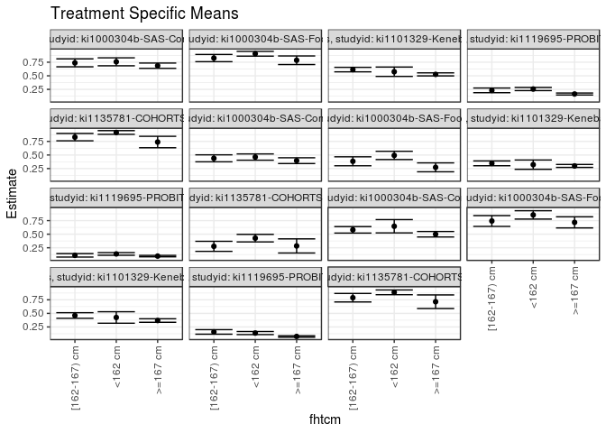

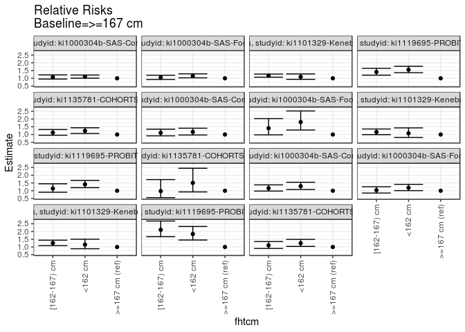

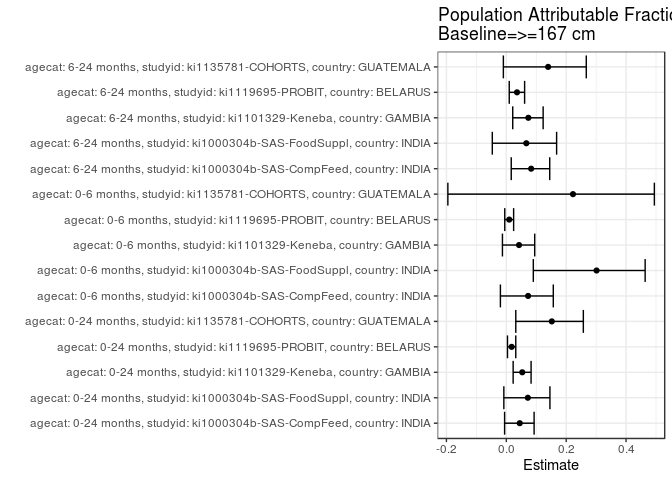

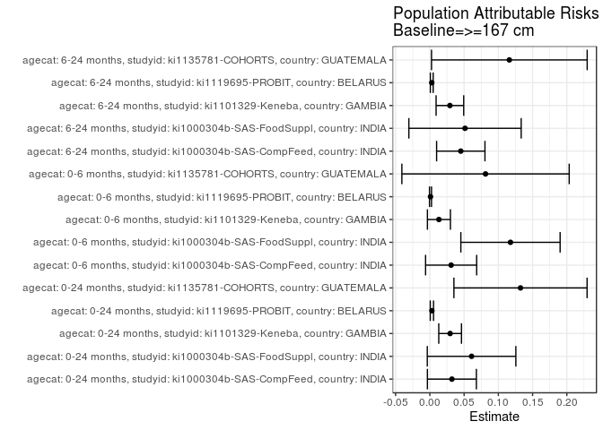

## Results Table

### Parameter: TSM

| agecat | studyid | country | intervention_level | baseline_level | estimate | ci_lower | ci_upper |
| --- | --- | --- | --- | --- | --- | --- | --- |
| 0-24 months | ki1000304b-SAS-CompFeed | INDIA | >=167 cm | NA | 0.6855654 | 0.6368377 | 0.7342931 |
| 0-24 months | ki1000304b-SAS-CompFeed | INDIA | <162 cm | NA | 0.7574565 | 0.6840593 | 0.8308537 |
| 0-24 months | ki1000304b-SAS-CompFeed | INDIA | [162-167) cm | NA | 0.7382486 | 0.6652182 | 0.8112791 |
| 0-24 months | ki1000304b-SAS-FoodSuppl | INDIA | >=167 cm | NA | 0.7862094 | 0.7074339 | 0.8649848 |
| 0-24 months | ki1000304b-SAS-FoodSuppl | INDIA | <162 cm | NA | 0.9056028 | 0.8620145 | 0.9491911 |
| 0-24 months | ki1000304b-SAS-FoodSuppl | INDIA | [162-167) cm | NA | 0.8266917 | 0.7602269 | 0.8931565 |
| 0-24 months | ki1101329-Keneba | GAMBIA | >=167 cm | NA | 0.5261275 | 0.4981040 | 0.5541510 |
| 0-24 months | ki1101329-Keneba | GAMBIA | <162 cm | NA | 0.5748043 | 0.4887047 | 0.6609039 |
| 0-24 months | ki1101329-Keneba | GAMBIA | [162-167) cm | NA | 0.6143614 | 0.5726453 | 0.6560775 |
| 0-24 months | ki1119695-PROBIT | BELARUS | >=167 cm | NA | 0.1649051 | 0.1466133 | 0.1831969 |
| 0-24 months | ki1119695-PROBIT | BELARUS | <162 cm | NA | 0.2565591 | 0.2274999 | 0.2856183 |
| 0-24 months | ki1119695-PROBIT | BELARUS | [162-167) cm | NA | 0.2321391 | 0.1892080 | 0.2750703 |
| 0-24 months | ki1135781-COHORTS | GUATEMALA | >=167 cm | NA | 0.7386470 | 0.6329531 | 0.8443408 |
| 0-24 months | ki1135781-COHORTS | GUATEMALA | <162 cm | NA | 0.9147571 | 0.8808232 | 0.9486909 |
| 0-24 months | ki1135781-COHORTS | GUATEMALA | [162-167) cm | NA | 0.8287499 | 0.7607936 | 0.8967062 |
| 0-6 months | ki1000304b-SAS-CompFeed | INDIA | >=167 cm | NA | 0.3954678 | 0.3423726 | 0.4485630 |
| 0-6 months | ki1000304b-SAS-CompFeed | INDIA | <162 cm | NA | 0.4620344 | 0.4045899 | 0.5194790 |
| 0-6 months | ki1000304b-SAS-CompFeed | INDIA | [162-167) cm | NA | 0.4387289 | 0.3747820 | 0.5026759 |
| 0-6 months | ki1000304b-SAS-FoodSuppl | INDIA | >=167 cm | NA | 0.2727238 | 0.1909968 | 0.3544509 |
| 0-6 months | ki1000304b-SAS-FoodSuppl | INDIA | <162 cm | NA | 0.4921561 | 0.4159350 | 0.5683773 |
| 0-6 months | ki1000304b-SAS-FoodSuppl | INDIA | [162-167) cm | NA | 0.3839662 | 0.3015811 | 0.4663514 |
| 0-6 months | ki1101329-Keneba | GAMBIA | >=167 cm | NA | 0.2984267 | 0.2711035 | 0.3257499 |
| 0-6 months | ki1101329-Keneba | GAMBIA | <162 cm | NA | 0.3221267 | 0.2365670 | 0.4076863 |
| 0-6 months | ki1101329-Keneba | GAMBIA | [162-167) cm | NA | 0.3463641 | 0.3020269 | 0.3907014 |
| 0-6 months | ki1119695-PROBIT | BELARUS | >=167 cm | NA | 0.0966782 | 0.0836510 | 0.1097055 |
| 0-6 months | ki1119695-PROBIT | BELARUS | <162 cm | NA | 0.1365984 | 0.1124359 | 0.1607610 |
| 0-6 months | ki1119695-PROBIT | BELARUS | [162-167) cm | NA | 0.1106102 | 0.0789395 | 0.1422808 |
| 0-6 months | ki1135781-COHORTS | GUATEMALA | >=167 cm | NA | 0.2836989 | 0.1536468 | 0.4137510 |
| 0-6 months | ki1135781-COHORTS | GUATEMALA | <162 cm | NA | 0.4271675 | 0.3576419 | 0.4966931 |
| 0-6 months | ki1135781-COHORTS | GUATEMALA | [162-167) cm | NA | 0.2765943 | 0.1841788 | 0.3690097 |
| 6-24 months | ki1000304b-SAS-CompFeed | INDIA | >=167 cm | NA | 0.4989882 | 0.4484602 | 0.5495162 |
| 6-24 months | ki1000304b-SAS-CompFeed | INDIA | <162 cm | NA | 0.6460631 | 0.5238846 | 0.7682415 |
| 6-24 months | ki1000304b-SAS-CompFeed | INDIA | [162-167) cm | NA | 0.5800966 | 0.5207037 | 0.6394895 |
| 6-24 months | ki1000304b-SAS-FoodSuppl | INDIA | >=167 cm | NA | 0.7175603 | 0.6153147 | 0.8198058 |
| 6-24 months | ki1000304b-SAS-FoodSuppl | INDIA | <162 cm | NA | 0.8548585 | 0.7780706 | 0.9316464 |
| 6-24 months | ki1000304b-SAS-FoodSuppl | INDIA | [162-167) cm | NA | 0.7429104 | 0.6436770 | 0.8421439 |
| 6-24 months | ki1101329-Keneba | GAMBIA | >=167 cm | NA | 0.3684894 | 0.3359348 | 0.4010441 |
| 6-24 months | ki1101329-Keneba | GAMBIA | <162 cm | NA | 0.4247250 | 0.3188046 | 0.5306455 |
| 6-24 months | ki1101329-Keneba | GAMBIA | [162-167) cm | NA | 0.4611058 | 0.4099595 | 0.5122520 |
| 6-24 months | ki1119695-PROBIT | BELARUS | >=167 cm | NA | 0.0751327 | 0.0615495 | 0.0887159 |
| 6-24 months | ki1119695-PROBIT | BELARUS | <162 cm | NA | 0.1379069 | 0.1098315 | 0.1659824 |
| 6-24 months | ki1119695-PROBIT | BELARUS | [162-167) cm | NA | 0.1584593 | 0.1168640 | 0.2000545 |
| 6-24 months | ki1135781-COHORTS | GUATEMALA | >=167 cm | NA | 0.7146020 | 0.5895341 | 0.8396699 |
| 6-24 months | ki1135781-COHORTS | GUATEMALA | <162 cm | NA | 0.8873753 | 0.8437927 | 0.9309579 |
| 6-24 months | ki1135781-COHORTS | GUATEMALA | [162-167) cm | NA | 0.7886573 | 0.7102869 | 0.8670277 |

### Parameter: E(Y)

| agecat | studyid | country | intervention_level | baseline_level | estimate | ci_lower | ci_upper |
| --- | --- | --- | --- | --- | --- | --- | --- |
| 0-24 months | ki1000304b-SAS-CompFeed | INDIA | NA | NA | 0.7177508 | 0.6751525 | 0.7603491 |
| 0-24 months | ki1000304b-SAS-FoodSuppl | INDIA | NA | NA | 0.8471178 | 0.8117623 | 0.8824733 |
| 0-24 months | ki1101329-Keneba | GAMBIA | NA | NA | 0.5557284 | 0.5335489 | 0.5779078 |
| 0-24 months | ki1119695-PROBIT | BELARUS | NA | NA | 0.1679030 | 0.1492221 | 0.1865839 |
| 0-24 months | ki1135781-COHORTS | GUATEMALA | NA | NA | 0.8709677 | 0.8414356 | 0.9004999 |
| 0-6 months | ki1000304b-SAS-CompFeed | INDIA | NA | NA | 0.4265193 | 0.3923837 | 0.4606550 |
| 0-6 months | ki1000304b-SAS-FoodSuppl | INDIA | NA | NA | 0.3904282 | 0.3423793 | 0.4384771 |
| 0-6 months | ki1101329-Keneba | GAMBIA | NA | NA | 0.3116657 | 0.2897893 | 0.3335421 |
| 0-6 months | ki1119695-PROBIT | BELARUS | NA | NA | 0.0976310 | 0.0843265 | 0.1109356 |
| 0-6 months | ki1135781-COHORTS | GUATEMALA | NA | NA | 0.3649852 | 0.3135088 | 0.4164615 |
| 6-24 months | ki1000304b-SAS-CompFeed | INDIA | NA | NA | 0.5441478 | 0.5023342 | 0.5859615 |
| 6-24 months | ki1000304b-SAS-FoodSuppl | INDIA | NA | NA | 0.7689076 | 0.7152410 | 0.8225741 |
| 6-24 months | ki1101329-Keneba | GAMBIA | NA | NA | 0.3977695 | 0.3716030 | 0.4239360 |
| 6-24 months | ki1119695-PROBIT | BELARUS | NA | NA | 0.0779232 | 0.0640302 | 0.0918162 |
| 6-24 months | ki1135781-COHORTS | GUATEMALA | NA | NA | 0.8306452 | 0.7924799 | 0.8688104 |

### Parameter: RR

| agecat | studyid | country | intervention_level | baseline_level | estimate | ci_lower | ci_upper |
| --- | --- | --- | --- | --- | --- | --- | --- |
| 0-24 months | ki1000304b-SAS-CompFeed | INDIA | >=167 cm | >=167 cm | 1.0000000 | 1.0000000 | 1.000000 |
| 0-24 months | ki1000304b-SAS-CompFeed | INDIA | <162 cm | >=167 cm | 1.1048640 | 1.0086888 | 1.210209 |
| 0-24 months | ki1000304b-SAS-CompFeed | INDIA | [162-167) cm | >=167 cm | 1.0768464 | 0.9519697 | 1.218104 |
| 0-24 months | ki1000304b-SAS-FoodSuppl | INDIA | >=167 cm | >=167 cm | 1.0000000 | 1.0000000 | 1.000000 |
| 0-24 months | ki1000304b-SAS-FoodSuppl | INDIA | <162 cm | >=167 cm | 1.1518596 | 1.0311547 | 1.286694 |
| 0-24 months | ki1000304b-SAS-FoodSuppl | INDIA | [162-167) cm | >=167 cm | 1.0514906 | 0.9251783 | 1.195048 |
| 0-24 months | ki1101329-Keneba | GAMBIA | >=167 cm | >=167 cm | 1.0000000 | 1.0000000 | 1.000000 |
| 0-24 months | ki1101329-Keneba | GAMBIA | <162 cm | >=167 cm | 1.0925189 | 0.9323679 | 1.280179 |
| 0-24 months | ki1101329-Keneba | GAMBIA | [162-167) cm | >=167 cm | 1.1677044 | 1.0722746 | 1.271627 |
| 0-24 months | ki1119695-PROBIT | BELARUS | >=167 cm | >=167 cm | 1.0000000 | 1.0000000 | 1.000000 |
| 0-24 months | ki1119695-PROBIT | BELARUS | <162 cm | >=167 cm | 1.5557983 | 1.3625179 | 1.776497 |
| 0-24 months | ki1119695-PROBIT | BELARUS | [162-167) cm | >=167 cm | 1.4077134 | 1.2027888 | 1.647552 |
| 0-24 months | ki1135781-COHORTS | GUATEMALA | >=167 cm | >=167 cm | 1.0000000 | 1.0000000 | 1.000000 |
| 0-24 months | ki1135781-COHORTS | GUATEMALA | <162 cm | >=167 cm | 1.2384226 | 1.0683741 | 1.435537 |
| 0-24 months | ki1135781-COHORTS | GUATEMALA | [162-167) cm | >=167 cm | 1.1219837 | 0.9515902 | 1.322888 |
| 0-6 months | ki1000304b-SAS-CompFeed | INDIA | >=167 cm | >=167 cm | 1.0000000 | 1.0000000 | 1.000000 |
| 0-6 months | ki1000304b-SAS-CompFeed | INDIA | <162 cm | >=167 cm | 1.1683238 | 0.9695360 | 1.407870 |
| 0-6 months | ki1000304b-SAS-CompFeed | INDIA | [162-167) cm | >=167 cm | 1.1093923 | 0.9141404 | 1.346348 |
| 0-6 months | ki1000304b-SAS-FoodSuppl | INDIA | >=167 cm | >=167 cm | 1.0000000 | 1.0000000 | 1.000000 |
| 0-6 months | ki1000304b-SAS-FoodSuppl | INDIA | <162 cm | >=167 cm | 1.8045953 | 1.2921316 | 2.520304 |
| 0-6 months | ki1000304b-SAS-FoodSuppl | INDIA | [162-167) cm | >=167 cm | 1.4078939 | 0.9780512 | 2.026648 |
| 0-6 months | ki1101329-Keneba | GAMBIA | >=167 cm | >=167 cm | 1.0000000 | 1.0000000 | 1.000000 |
| 0-6 months | ki1101329-Keneba | GAMBIA | <162 cm | >=167 cm | 1.0794163 | 0.8153513 | 1.429003 |
| 0-6 months | ki1101329-Keneba | GAMBIA | [162-167) cm | >=167 cm | 1.1606337 | 0.9923856 | 1.357406 |
| 0-6 months | ki1119695-PROBIT | BELARUS | >=167 cm | >=167 cm | 1.0000000 | 1.0000000 | 1.000000 |
| 0-6 months | ki1119695-PROBIT | BELARUS | <162 cm | >=167 cm | 1.4129181 | 1.1987332 | 1.665373 |
| 0-6 months | ki1119695-PROBIT | BELARUS | [162-167) cm | >=167 cm | 1.1441059 | 0.9036515 | 1.448543 |
| 0-6 months | ki1135781-COHORTS | GUATEMALA | >=167 cm | >=167 cm | 1.0000000 | 1.0000000 | 1.000000 |
| 0-6 months | ki1135781-COHORTS | GUATEMALA | <162 cm | >=167 cm | 1.5057073 | 0.9250737 | 2.450782 |
| 0-6 months | ki1135781-COHORTS | GUATEMALA | [162-167) cm | >=167 cm | 0.9749571 | 0.5525979 | 1.720132 |
| 6-24 months | ki1000304b-SAS-CompFeed | INDIA | >=167 cm | >=167 cm | 1.0000000 | 1.0000000 | 1.000000 |
| 6-24 months | ki1000304b-SAS-CompFeed | INDIA | <162 cm | >=167 cm | 1.2947461 | 1.0827519 | 1.548247 |
| 6-24 months | ki1000304b-SAS-CompFeed | INDIA | [162-167) cm | >=167 cm | 1.1625456 | 0.9803834 | 1.378555 |
| 6-24 months | ki1000304b-SAS-FoodSuppl | INDIA | >=167 cm | >=167 cm | 1.0000000 | 1.0000000 | 1.000000 |
| 6-24 months | ki1000304b-SAS-FoodSuppl | INDIA | <162 cm | >=167 cm | 1.1913403 | 1.0063965 | 1.410271 |
| 6-24 months | ki1000304b-SAS-FoodSuppl | INDIA | [162-167) cm | >=167 cm | 1.0353283 | 0.8510209 | 1.259551 |
| 6-24 months | ki1101329-Keneba | GAMBIA | >=167 cm | >=167 cm | 1.0000000 | 1.0000000 | 1.000000 |
| 6-24 months | ki1101329-Keneba | GAMBIA | <162 cm | >=167 cm | 1.1526112 | 0.8852424 | 1.500733 |
| 6-24 months | ki1101329-Keneba | GAMBIA | [162-167) cm | >=167 cm | 1.2513405 | 1.0875639 | 1.439780 |
| 6-24 months | ki1119695-PROBIT | BELARUS | >=167 cm | >=167 cm | 1.0000000 | 1.0000000 | 1.000000 |
| 6-24 months | ki1119695-PROBIT | BELARUS | <162 cm | >=167 cm | 1.8355116 | 1.4494962 | 2.324327 |
| 6-24 months | ki1119695-PROBIT | BELARUS | [162-167) cm | >=167 cm | 2.1090585 | 1.6631705 | 2.674487 |
| 6-24 months | ki1135781-COHORTS | GUATEMALA | >=167 cm | >=167 cm | 1.0000000 | 1.0000000 | 1.000000 |
| 6-24 months | ki1135781-COHORTS | GUATEMALA | <162 cm | >=167 cm | 1.2417756 | 1.0356858 | 1.488875 |
| 6-24 months | ki1135781-COHORTS | GUATEMALA | [162-167) cm | >=167 cm | 1.1036315 | 0.9030858 | 1.348712 |

### Parameter: PAR

| agecat | studyid | country | intervention_level | baseline_level | estimate | ci_lower | ci_upper |
| --- | --- | --- | --- | --- | --- | --- | --- |
| 0-24 months | ki1000304b-SAS-CompFeed | INDIA | >=167 cm | NA | 0.0321854 | -0.0035581 | 0.0679290 |
| 0-24 months | ki1000304b-SAS-FoodSuppl | INDIA | >=167 cm | NA | 0.0609084 | -0.0037274 | 0.1255443 |
| 0-24 months | ki1101329-Keneba | GAMBIA | >=167 cm | NA | 0.0296008 | 0.0130311 | 0.0461706 |
| 0-24 months | ki1119695-PROBIT | BELARUS | >=167 cm | NA | 0.0029979 | 0.0006219 | 0.0053739 |
| 0-24 months | ki1135781-COHORTS | GUATEMALA | >=167 cm | NA | 0.1323208 | 0.0351210 | 0.2295205 |
| 0-6 months | ki1000304b-SAS-CompFeed | INDIA | >=167 cm | NA | 0.0310515 | -0.0062271 | 0.0683302 |
| 0-6 months | ki1000304b-SAS-FoodSuppl | INDIA | >=167 cm | NA | 0.1177044 | 0.0452578 | 0.1901510 |
| 0-6 months | ki1101329-Keneba | GAMBIA | >=167 cm | NA | 0.0132390 | -0.0035360 | 0.0300140 |
| 0-6 months | ki1119695-PROBIT | BELARUS | >=167 cm | NA | 0.0009528 | -0.0005191 | 0.0024246 |
| 0-6 months | ki1135781-COHORTS | GUATEMALA | >=167 cm | NA | 0.0812862 | -0.0408317 | 0.2034042 |
| 6-24 months | ki1000304b-SAS-CompFeed | INDIA | >=167 cm | NA | 0.0451596 | 0.0098738 | 0.0804455 |
| 6-24 months | ki1000304b-SAS-FoodSuppl | INDIA | >=167 cm | NA | 0.0513473 | -0.0306268 | 0.1333214 |
| 6-24 months | ki1101329-Keneba | GAMBIA | >=167 cm | NA | 0.0292801 | 0.0091255 | 0.0494347 |
| 6-24 months | ki1119695-PROBIT | BELARUS | >=167 cm | NA | 0.0027905 | 0.0007405 | 0.0048405 |
| 6-24 months | ki1135781-COHORTS | GUATEMALA | >=167 cm | NA | 0.1160432 | 0.0024327 | 0.2296537 |

### Parameter: PAF

| agecat | studyid | country | intervention_level | baseline_level | estimate | ci_lower | ci_upper |
| --- | --- | --- | --- | --- | --- | --- | --- |
| 0-24 months | ki1000304b-SAS-CompFeed | INDIA | >=167 cm | NA | 0.0448421 | -0.0056892 | 0.0928344 |
| 0-24 months | ki1000304b-SAS-FoodSuppl | INDIA | >=167 cm | NA | 0.0719008 | -0.0082406 | 0.1456721 |
| 0-24 months | ki1101329-Keneba | GAMBIA | >=167 cm | NA | 0.0532649 | 0.0228401 | 0.0827425 |
| 0-24 months | ki1119695-PROBIT | BELARUS | >=167 cm | NA | 0.0178549 | 0.0039180 | 0.0315968 |
| 0-24 months | ki1135781-COHORTS | GUATEMALA | >=167 cm | NA | 0.1519239 | 0.0316450 | 0.2572630 |
| 0-6 months | ki1000304b-SAS-CompFeed | INDIA | >=167 cm | NA | 0.0728022 | -0.0197261 | 0.1569346 |
| 0-6 months | ki1000304b-SAS-FoodSuppl | INDIA | >=167 cm | NA | 0.3014751 | 0.0902040 | 0.4636852 |
| 0-6 months | ki1101329-Keneba | GAMBIA | >=167 cm | NA | 0.0424781 | -0.0129168 | 0.0948436 |
| 0-6 months | ki1119695-PROBIT | BELARUS | >=167 cm | NA | 0.0097588 | -0.0051631 | 0.0244592 |
| 0-6 months | ki1135781-COHORTS | GUATEMALA | >=167 cm | NA | 0.2227111 | -0.1952036 | 0.4944978 |
| 6-24 months | ki1000304b-SAS-CompFeed | INDIA | >=167 cm | NA | 0.0829915 | 0.0164857 | 0.1450001 |
| 6-24 months | ki1000304b-SAS-FoodSuppl | INDIA | >=167 cm | NA | 0.0667795 | -0.0467800 | 0.1680196 |
| 6-24 months | ki1101329-Keneba | GAMBIA | >=167 cm | NA | 0.0736107 | 0.0214368 | 0.1230029 |
| 6-24 months | ki1119695-PROBIT | BELARUS | >=167 cm | NA | 0.0358112 | 0.0098175 | 0.0611225 |
| 6-24 months | ki1135781-COHORTS | GUATEMALA | >=167 cm | NA | 0.1397025 | -0.0098249 | 0.2670889 |